Ficha del establecimiento

# Escuela General Básica Santa Fe

RBD **9413**San MiguelEscuela o liceo

416estudiantes matriculadosCorte Agosto 2026

Mujeres45,7%190 est.

Hombres54,3%226 est.

Chilenos/as50,5%210 est.

Extranjeros/as49,5%206 est.

Actualizada al 05-10-2026

💻Ver ficha completaVersión para computador, con mapas y gráficos interactivos. Pesa varios MB: mejor ábrela con wifi.

🏛️Identificación

## Identificación del establecimiento

Los datos de contacto y las características básicas del establecimiento, tal como están registrados en el Ministerio de Educación. **Si algo está mal o falta, escríbenos** y lo corregimos en la próxima actualización.

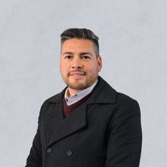

Director o directora

José Luis Echeverría Isamit

**Nombre**

Escuela General Básica Santa Fe

**RBD**

9413

**Dirección**

Santa Fe 528

**Comuna**

San Miguel

**Tipo**

Escuela o liceo

**Estado**

✅En funcionamiento

**Director/a**

José Luis Echeverría Isamit

**Correo**

escuelasantafe@slepsantarosa.cl

**Teléfono**

443144686

**Sitio web**

WWW.ESCUELASANTAFE464.BLOGSPOT.COM

**Matrícula**

GRATUITO

**Sostenedor**

El sostenedor corresponde a una persona jurídica

**Orientación**

Orientación religiosa Evangélica

### Niveles que imparte

✓ 🧸 Educación Parvularia✓ 🎒 Enseñanza Básica Niños

### Vulnerabilidad del alumnado

Índice de vulnerabilidad (IVE)

91,4%

Lo calcula JUNAEB y sirve para asignar programas de apoyo.

0%100%

Este establecimientoPromedio de la comuna 62%

Prioritarios en Básica

77,7%

Estudiantes en 1ª, 2ª o 3ª prioridad.

**Un IVE más alto significa más necesidad de apoyo**, no peor calidad. Se usa para decidir a qué establecimientos llegan primero los programas de alimentación, salud y becas.

### Apoyos profesionales al aprendizaje

✓ 📚 Reforzamiento✓ 🧠 Psicólogo/a✓ 🧭 Orientador/a✓ 👩‍🏫 Profesor/a de educación especial✓ 🤝 Asistente social✓ 🗣️ Fonoaudiólogo/a✓ ➕ Otro: TERAPEUTA OCUPACIONAL🧩 Psicopedagogo/a🎓 Orientación vocacional

### Infraestructura y atención a la diversidad

✓ 📚 Biblioteca✓ 🔬 Laboratorio✓ 🏛️ Sala multiuso✓ 🌐 Computadores con internet✓ 🖥️ Sala de informática✓ 📽️ Sala audiovisual✓ 🏟️ Cancha deportiva✓ ♿ Accesibilidad NEE✓ ➕ Otra: SALA PSICOMOTRICIDAD, SALA PIZARRA INTERACTIV💻 Computadores🤾 Gimnasio

✓ 🧠 Discapacidad intelectual✓ 🦽 Discapacidad motora✓ 🧩 Trastorno del espectro autista✓ 💬 Trastornos de la comunicación✓ 📖 Dificultades de aprendizaje✓ 🗣️ Trastorno específico del lenguaje✓ 🎯 Déficit atencional✓ 📊 Funcionamiento intelectual limítrofe👁️ Discapacidad visual👂 Discapacidad auditiva

Las etiquetas con ✓ son las que el establecimiento declaró en el directorio oficial; las grises no están marcadas.

### Jornada Escolar Completa (JEC)

Cursos con jornada completa

Cursos sin jornada completa

2

**Ver curso por curso**

[output not shown]

Con **Jornada Escolar Completa** los estudiantes tienen más horas de clases al día y almuerzan en el establecimiento.

### Idiomas

**Inglés en Enseñanza Básica**

Básico

**Lengua indígena (PEIB)**

MAPUZUGUN

### Certificación ambiental (SNCAE)

El establecimiento no tiene certificación del Sistema Nacional de Certificación Ambiental de Establecimientos Educacionales (SNCAE).

### Concentración de alumnado prioritario

Concentración 2026

49,4%

▼3,39 pts

Porcentaje de estudiantes prioritarios reconocidos por el Mineduc.

0%100%

Concentración del establecimiento

Concentración 2025

52,8%

Resolución exenta

2026

Observación del Ministerio: **Sin ACAP 2025-2026**.

La **concentración de prioritarios** define cuánta Subvención Escolar Preferencial (SEP) recibe el establecimiento. Sobre 60 % da acceso a la asignación por concentración.

### Requisitos para postular

✓ 🎂 Cumplir la edad mínima✓ 📄 Certificado de nacimiento✓ 📊 Certificado de notas✓ 📝 Informe de personalidad✓ ✍️ Firmar el proyecto educativo✓ ⚖️ Firmar el reglamento de convivencia🏠 Ficha de protección social🧪 Test de intereses♿ Informe de necesidades educativas📋 Examen de ingreso👥 Entrevista con apoderados🎲 Sorteo💍 Certificado de matrimonio⛪ Certificado de bautismo⛪ Certificado de matrimonio religioso💰 Pago de postulación➕ Otro

Desde el Sistema de Admisión Escolar, los establecimientos públicos **no pueden seleccionar** por rendimiento ni por antecedentes socioeconómicos. Estos son los antecedentes administrativos que el establecimiento declara pedir.

**Equipo del SLEP que acompaña al establecimiento**

**Asesor/a territorial**

RAÚL VASQUEZ DEL PINO

**Correo UTP**

utp.escuelasantafe@slepsantarosa.cl

**Correo Inspectoría**

inspectoria.escuelasantafe@slepsantarosa.cl

🏫Matrícula

## Matrícula y asistencia

Cuántos estudiantes tiene el establecimiento, quiénes son y cuántos días van efectivamente a clases. **La asistencia es el porcentaje de días que los estudiantes asistieron** sobre los días en que estuvieron matriculados.

Matrícula · Agosto 2026

416

▲2,7%

Variación desde el primer mes del año escolar.

1141.024

Este establecimientoPromedio del SLEP 333

Asistencia promedio

89,6%

Días asistidos sobre días matriculados.

69,0%91,1%

Este añoPromedio de años anteriores 82,2%

Cursos

11

Niveles

2

Matrícula regular

416

Estudiantes en la modalidad regular del establecimiento.

Matrícula no regular

0

Modalidades de adultos, reingreso o validación de estudios.

Matrícula mes a mes · 2026

Cuántos estudiantes había registrados al cierre de cada mes.

Asistencia mes a mes · 2026

Porcentaje de días asistidos sobre los días en que el estudiante estuvo matriculado.

Matrícula año a año

Matrícula del último mes de cada año escolar.

### Quiénes estudian acá

Por género

Hombres · 226Mujeres · 190

Por origen

Chilenos/as · 210Extranjeros/as · 206Nacionalizados/as · 0

Nacionalidades presentes

Número de estudiantes por país de nacimiento declarado.

🇨🇱 Chilena269

🇻🇪 Venezolana65

❔ Sin información41

🇨🇴 Colombiana12

🇵🇪 Peruana12

🇪🇨 Ecuatoriana5

Otros9

Pueblos originarios

Estudiantes que declaran pertenecer a un pueblo originario.

🌿 Mapuche10

🌐 Otra etnia1

🏺 Diaguita1

### Por nivel de enseñanza

Matrícula por nivel

🧸 Educación Parvularia57

🎒 Enseñanza Básica Niños359

Asistencia por nivel

La escala va de 0 % a 100 %.

🧸 Educación Parvularia85,1%

🎒 Enseñanza Básica Niños90,3%

### Asistencia por grupo

Asistencia por género

Promedio ponderado por el número de estudiantes de cada grupo.

Hombres88,6%

Mujeres90,9%

Asistencia por origen

Chilenos/as88,5%

Extranjeros/as90,7%

Asistencia por nacionalidad

Solo los seis grupos con más estudiantes.

🇨🇱 Chilena90,5%

🇻🇪 Venezolana88,7%

❔ Sin información88,1%

🇨🇴 Colombiana86,9%

🇵🇪 Peruana83,7%

🇪🇨 Ecuatoriana0,0%

Asistencia por pueblo originario

🌿 Mapuche89,5%

🌐 Otra etnia0,0%

🏺 Diaguita0,0%

**Ver el detalle curso por curso (11 cursos)**

| Curso | Matrícula | Asistencia % |
| --- | --- | --- |
| Pre-kínder A | 25 | 83,9 |
| Kínder A | 32 | 86,1 |
| 1° Básico A | 36 | 89,6 |
| 2° Básico A | 44 | 89,5 |
| 3° Básico A | 27 | 92,1 |
| 3° Básico B | 27 | 92 |
| 4° Básico A | 45 | 89,3 |
| 5° Básico A | 45 | 91,2 |
| 6° Básico A | 45 | 89,5 |
| 7° Básico A | 45 | 91,6 |
| 8° Básico A | 45 | 89,2 |

**Ver la matrícula año a año, con su variación**

| Periodo | Matrícula | Variación | Cambio |
| --- | --- | --- | --- |
| 2026 | 416 | −5,0 | −1,2% |
| 2025 | 421 | +2,0 | +0,5% |
| 2024 | 419 | −4,0 | −0,9% |
| 2023 | 423 | +19,0 | +4,7% |
| 2022 | 404 | +31,0 | +8,3% |
| 2019 | 373 | +34,0 | +10,0% |
| 2018 | 339 | +77,0 | +29,4% |
| 2017 | 262 | +4,0 | +1,6% |
| 2016 | 258 | — | — |

**Ver la asistencia año a año, con su variación**

| Periodo | Asistencia | Variación | Cambio |
| --- | --- | --- | --- |
| 2026 | 89,6% | +7,7 pts | +9,4% |
| 2025 | 81,9% | +11,3 pts | +16,0% |
| 2024 | 70,6% | −10,8 pts | −13,3% |
| 2023 | 81,4% | =0,0 pts | =0,0% |
| 2022 | 81,4% | −6,1 pts | −7,0% |
| 2019 | 87,5% | +2,4 pts | +2,8% |
| 2018 | 85,1% | +0,3 pts | +0,4% |
| 2017 | 84,8% | =0,0 pts | =0,0% |
| 2016 | 84,8% | — | — |

La matrícula se cuenta al cierre de cada mes, así que los cambios durante el año reflejan traslados y retiros. Corte usado: **Agosto 2026**.

🤝Vida escolar

## Vida escolar y comunidad

Qué actividades ofrece el establecimiento fuera de las clases, cómo se organiza con las familias y quiénes representan a la comunidad. **Las etiquetas con ✓ son las que el establecimiento declaró** en el directorio oficial del Ministerio; las grises no están marcadas.

### Talleres y actividades para estudiantes

✓ 🧭 Orientación✓ 🤝 Convivencia✓ 🚫 Prevención drogas✓ ❤️ Educación sexual✓ 🌱 Medio ambiente✓ 🌟 Vida sana✓ 🫂 Acción social✝️ Pastoral➕ Otra

Actividades de formación: orientación, convivencia, prevención y vida sana.

✓ ✂️ Manualidades✓ 🎵 Música✓ 🩰 Danza o ballet✓ 💻 Taller TIC✓ ➕ Otro: TALLER DE ROBOTICA🎭 Teatro📚 Literatura🎨 Artes plásticas🎓 Preuniversitario

Talleres de arte, cultura y tecnología fuera del horario de clases.

✓ 🥅 Baby fútbol✓ 🏐 Vóleibol✓ 🏀 Básquetbol✓ 🤸 Gimnasia✓ 🏓 Tenis de mesa✓ ♟️ Ajedrez✓ ➕ Otro: ESCALADA⚽ Fútbol🏃 Atletismo🏊 Natación🎾 Tenis

Disciplinas deportivas que ofrece el establecimiento.

### Trabajo con las familias

✓ ➕ Otra: FERIA INTERCULTURAL👪 Talleres de formación🎉 Actividades de integración📈 Perfeccionamiento

✓ 📒 Libreta de comunicaciones✓ 🌐 Web y redes sociales✓ 🗣️ Consejo escolar✓ 📄 Reuniones generales✓ 👥 Entrevistas individuales✓ ➕ Otro: CITACIONES, COMUNICADOS, DIARIO MURAL, SINEDUC

Por dónde el establecimiento se comunica con apoderados y apoderadas.

### Organizaciones de la comunidad

**Centro de Padres**

Constituido

**Personalidad jurídica**

Vencida

**Última elección de directiva**

**Centro de Estudiantes**

Constituido

**Representante del sostenedor en el Consejo Escolar**

Eiden Viera Pardo

**Acompañamiento del Consejo Escolar**

Eiden Viera Pardo

Para contactar al centro de padres o al centro de estudiantes, escribe al establecimiento: sus datos están más arriba.

El **Consejo Escolar** es la instancia donde se juntan dirección, docentes, asistentes, apoderados y estudiantes para conversar sobre la marcha del establecimiento.

### Normativa y conectividad

**Uso de uniforme**

Uniforme propio del establecimiento

**Tipo de conexión**

Fibra óptica

**Velocidad de internet**

Sin información

🧭Gestión

## Instrumentos de gestión: PEI y PME

El **PEI** dice quién quiere ser el establecimiento: su misión, su visión y sus sellos. El **PME** dice qué va a hacer este año para lograrlo, con responsables y presupuesto. Son los dos documentos que ordenan el trabajo.

### Proyecto Educativo Institucional (PEI)

**Misión**

La Escuela Santa Fe, entrega a nuestros y nuestras estudiantes una educación basada en el respeto, inclusión y sana convivencia escolar, favoreciendo de esta manera la autonomía de los aprendizajes de cada estudiante y con ello, que asuman de forma responsable su futuro mediante saberes y competencias necesarias que la sociedad actual les demande, desempeñando un rol constructivo y transformador en conjunto con la ciudadanía.

**Visión**

La Escuela Santa Fe, busca consolidar una educación de calidad y equidad de género; basada en el desarrollo de competencias cognitivas, deportivas, artísticas, valóricas, democráticas y tecnológicas; que incorpore a los y las estudiantes de manera positiva en la sociedad y les facilite continuar en sus estudios acorde a sus intereses vocacionales, personales y colectivos.

### Énfasis declarados, en orden de prioridad

**1º**

Desarrollo integral

**2º**

Inclusivo

**3º**

Otro: TECNOLÓGICO, DEPORTIVO Y ARTÍSTICO

### Documentos oficiales

[📘Proyecto Educativo](https://wwwfs.mineduc.cl/Archivos/infoescuelas/documentos/9413/ProyectoEducativo9413.pdf)[⚖️Reglamento de Convivencia](https://wwwfs.mineduc.cl/Archivos/infoescuelas/documentos/9413/ReglamentodeConvivencia9413.pdf)[📊Reglamento de Evaluación](https://wwwfs.mineduc.cl/Archivos/infoescuelas/documentos/9413/ReglamentoDeEvaluacion9413.pdf)

### Plan de Mejoramiento Educativo (PME)

Acciones comprometidas

44

Inversión total del plan

$ 197.031.524

Dimensiones cubiertas

4

Acciones por dimensión

Las cuatro dimensiones del PME: gestión pedagógica, liderazgo, convivencia y recursos.

Gestión Pedagógica14

Convivencia Escolar11

Gestión de Recursos10

Liderazgo9

Quién lidera las acciones

Los cinco responsables con más acciones a cargo.

Director34

Jefe técnico5

Equipo de gestión2

Sostenedor2

Encargado de convivencia1

De dónde sale el financiamiento

Monto comprometido por fuente de recursos.

sep$ 193.826.010

faep$ 2.000.000

pro retencion$ 1.205.514

**Ver las 44 acciones del plan**

| Acción | Dimensión | Responsable | Monto |
| --- | --- | --- | --- |
| Apoyo a las Necesidades Educativas dde los estudiantes permanentes (excepcionalidades) | Gestión Pedagógica | Equipo de gestión | $ 4.378.968 |
| Aseguramiento de la preparación de la Enseñanza. | Gestión Pedagógica | Jefe técnico | $ 0 |
| Desarrollo Profesional Docente. | Gestión Pedagógica | Jefe técnico | $ 0 |
| Fortalecimiento de los aprendizajes. | Gestión Pedagógica | Director | $ 4.839.912 |
| Servicio de Plataforma Educativa. | Gestión Pedagógica | Jefe técnico | $ 2.698.728 |
| Aplicación y Monitoreo de instrumentos de diagnóstico de aprendizajes (DIA) | Gestión Pedagógica | Jefe técnico | $ 0 |
| Asistentes de aula Básica. | Gestión Pedagógica | Director | $ 25.473.408 |
| Asesoría técnica y actividad de formación, información y Orientación para las comunidades educativas | Gestión Pedagógica | Director | $ 0 |
| Co-docencia en aula profesores de asignatura y profesionales PIE. | Gestión Pedagógica | Jefe técnico | $ 0 |
| Extensión horaria para Niveles Sin JEC | Gestión Pedagógica | Equipo de gestión | $ 10.250.028 |
| Innovación pedagógica y tecnológica en el aula. | Gestión Pedagógica | Director | $ 3.940.009 |
| Plan de acompañamiento, (Decreto 67) | Gestión Pedagógica | Director | $ 2.535.192 |
| Plan de transición educativa, decreto 373 | Gestión Pedagógica | Director | $ 6.914.160 |
| Trabajo colaborativo Jugando con lo sonidos | Gestión Pedagógica | Director | $ 1.843.776 |
| Entrevista a docentes y asistentes de la educación. | Liderazgo | Director | $ 0 |
| Evaluación de proceso a los Docentes y Asistentes de la Educación. | Liderazgo | Director | $ 0 |
| Fortalecimiento al rol de Profesor jefe. | Liderazgo | Director | $ 2.535.192 |
| Visita de acompañamiento, asesoría y apoyo a los establecimientos | Liderazgo | Sostenedor | $ 0 |
| Contratación de Profesionales para Administración Central de la SLEP | Liderazgo | Sostenedor | $ 14.437.061 |
| Intervención en reuniones de apoderados | Liderazgo | Director | $ 0 |
| Jornada de autoevaluación institucional | Liderazgo | Director | $ 0 |
| Revisión y Actualización de instrumentos de gestión educativa. RIE, PEI, JEC, PLANES, Reglamento EVA | Liderazgo | Director | $ 0 |
| Sesiones de Consejo Escolar | Liderazgo | Director | $ 0 |
| Acciones educativas en género, disidencias y diversidad. | Convivencia Escolar | Director | $ 5.761.800 |
| Acciones educativas en, Deporte, cultura y medio ambiente. | Convivencia Escolar | Director | $ 10.140.768 |
| Acciones educativas y fortalecimiento de la formación ciudadana. | Convivencia Escolar | Director | $ 6.914.160 |
| Asistencia, permanencia y Revinculación (Contratación Dupla psicosocial) | Convivencia Escolar | Director | $ 44.360.520 |
| Huertos escolares y fortalecimiento de las áreas verdes, PHYMA | Convivencia Escolar | Director | $ 0 |
| Implementación y monitoreo del plan de convivencia escolar y apoyo socioemocional | Convivencia Escolar | Director | $ 1.265.211 |
| Feria Intercultural | Convivencia Escolar | Director | $ 2.949.550 |
| Sentido de pertenencia y eventos educativos/ culturales, Salidas Pedagógicas: Transporte y colación | Convivencia Escolar | Director | $ 2.000.000 |
| Autocuidado a docente y asistente de la educación. | Convivencia Escolar | Encargado de convivencia | $ 0 |
| Profesional de apoyo en primeros auxilios y de atención a las necesidades educativas. | Convivencia Escolar | Director | $ 11.366.784 |
| Implementación de sala de enfermería | Convivencia Escolar | Director | $ 0 |
| Innovación Educativa. | Gestión de Recursos | Director | $ 0 |
| Servicio de equipos multicopiadores para el Apoyo Pedagógico | Gestión de Recursos | Director | $ 2.417.989 |
| Adquisición de Material Escolar para el Apoyo al Aprendizaje | Gestión de Recursos | Director | $ 3.265.211 |
| Adquisición de material didáctico escolar, para el apoyo pedagógico. | Gestión de Recursos | Director | $ 1.912.889 |
| Gasto en Equipamiento en Apoyo Pedagógico: Musical y Deportivo | Gestión de Recursos | Director | $ 5.606.188 |
| Retención y fidelización de estudiantes. | Gestión de Recursos | Director | $ 4.949.550 |
| Talleres electivos de formación general, Artísticos, Deportivos, tecnológicos. | Gestión de Recursos | Director | $ 6.821.820 |
| Mobiliario y Otros: Equipos Informáticos, equipos de sonido y amplificación | Gestión de Recursos | Director | $ 0 |
| Plan anual de Compras 2025 | Gestión de Recursos | Director | $ 0 |
| Apoyo Soporte Técnico Administrativo en Informática y tecnología | Gestión de Recursos | Director | $ 7.452.650 |

**Ver plazos y estado de ejecución de cada acción**

| Acción | Inicio | Término | Nivel de ejecución |
| --- | --- | --- | --- |
| Apoyo a las Necesidades Educativas dde los estudiantes permanentes (excepcionalidades) | 03/3/2025 | 31/12/2025 | Implementado (100%) |
| Aseguramiento de la preparación de la Enseñanza. | 03/3/2025 | 31/12/2025 | Implementado (100%) |
| Desarrollo Profesional Docente. | 03/3/2025 | 31/12/2025 | Implementado (100%) |
| Fortalecimiento de los aprendizajes. | 03/3/2025 | 31/12/2025 | Implementado (100%) |
| Servicio de Plataforma Educativa. | 04/3/2025 | 31/12/2025 | Implementado (100%) |
| Aplicación y Monitoreo de instrumentos de diagnóstico de aprendizajes (DIA) | 03/3/2025 | 31/12/2025 | Implementado (100%) |
| Asistentes de aula Básica. | 04/3/2025 | 31/12/2025 | Implementado (100%) |
| Asesoría técnica y actividad de formación, información y Orientación para las comunidades educativas | 04/3/2025 | 31/12/2025 | Implementado (100%) |
| Co-docencia en aula profesores de asignatura y profesionales PIE. | 03/3/2025 | 31/12/2025 | Implementado (100%) |
| Extensión horaria para Niveles Sin JEC | 06/3/2025 | 31/12/2025 | Implementado (100%) |
| Innovación pedagógica y tecnológica en el aula. | 06/3/2025 | 31/12/2025 | Implementación avanzada (75% a 99%) |
| Plan de acompañamiento, (Decreto 67) | 03/3/2025 | 31/12/2025 | Implementado (100%) |
| Plan de transición educativa, decreto 373 | 03/3/2025 | 31/12/2025 | Implementado (100%) |
| Trabajo colaborativo Jugando con lo sonidos | 03/3/2025 | 31/12/2025 | Implementado (100%) |
| Entrevista a docentes y asistentes de la educación. | 03/3/2025 | 31/12/2025 | Implementado (100%) |
| Evaluación de proceso a los Docentes y Asistentes de la Educación. | 03/3/2025 | 31/12/2025 | Implementado (100%) |
| Fortalecimiento al rol de Profesor jefe. | 03/3/2025 | 31/12/2025 | Implementado (100%) |
| Visita de acompañamiento, asesoría y apoyo a los establecimientos | 03/3/2025 | 31/12/2025 | Implementado (100%) |
| Contratación de Profesionales para Administración Central de la SLEP | 05/3/2025 | 31/12/2025 | Implementado (100%) |
| Intervención en reuniones de apoderados | 03/3/2025 | 31/12/2025 | Implementado (100%) |
| Jornada de autoevaluación institucional | 03/3/2025 | 31/12/2025 | Implementado (100%) |
| Revisión y Actualización de instrumentos de gestión educativa. RIE, PEI, JEC, PLANES, Reglamento EVA | 03/3/2025 | 31/12/2025 | Implementado (100%) |
| Sesiones de Consejo Escolar | 03/3/2025 | 31/12/2025 | Implementado (100%) |
| Acciones educativas en género, disidencias y diversidad. | 03/3/2025 | 31/12/2025 | Implementado (100%) |
| Acciones educativas en, Deporte, cultura y medio ambiente. | 03/3/2025 | 31/12/2025 | Implementado (100%) |
| Acciones educativas y fortalecimiento de la formación ciudadana. | 03/3/2025 | 31/12/2025 | Implementado (100%) |
| Asistencia, permanencia y Revinculación (Contratación Dupla psicosocial) | 04/3/2025 | 31/12/2025 | Implementado (100%) |
| Huertos escolares y fortalecimiento de las áreas verdes, PHYMA | 06/3/2025 | 31/12/2025 | Implementado (100%) |
| Implementación y monitoreo del plan de convivencia escolar y apoyo socioemocional | 04/3/2025 | 31/12/2025 | Implementado (100%) |
| Feria Intercultural | 04/3/2025 | 31/12/2025 | Implementado parcialmente (25 a 49%) |
| Sentido de pertenencia y eventos educativos/ culturales, Salidas Pedagógicas: Transporte y colación | 05/3/2025 | 31/12/2025 | Implementado (100%) |
| Autocuidado a docente y asistente de la educación. | 03/3/2025 | 31/12/2025 | Implementado (100%) |
| Profesional de apoyo en primeros auxilios y de atención a las necesidades educativas. | 04/3/2025 | 31/12/2025 | Implementado (100%) |
| Implementación de sala de enfermería | 06/3/2025 | 31/12/2025 | Implementado (100%) |
| Innovación Educativa. | 03/3/2025 | 31/12/2025 | Implementado (100%) |
| Servicio de equipos multicopiadores para el Apoyo Pedagógico | 03/3/2025 | 31/12/2025 | Implementado (100%) |
| Adquisición de Material Escolar para el Apoyo al Aprendizaje | 03/3/2025 | 31/12/2025 | Implementado parcialmente (25 a 49%) |
| Adquisición de material didáctico escolar, para el apoyo pedagógico. | 03/3/2025 | 31/12/2025 | Implementado parcialmente (25 a 49%) |
| Gasto en Equipamiento en Apoyo Pedagógico: Musical y Deportivo | 03/3/2025 | 31/12/2025 | Implementado de manera adecuada (50% a 74%) |
| Retención y fidelización de estudiantes. | 03/3/2025 | 31/12/2025 | Implementado (100%) |
| Talleres electivos de formación general, Artísticos, Deportivos, tecnológicos. | 03/3/2025 | 31/12/2025 | Implementado (100%) |
| Mobiliario y Otros: Equipos Informáticos, equipos de sonido y amplificación | 03/3/2025 | 31/12/2025 | No Implementado (0%) |
| Plan anual de Compras 2025 | 03/3/2025 | 31/12/2025 | Implementado (100%) |
| Apoyo Soporte Técnico Administrativo en Informática y tecnología | 03/3/2025 | 31/12/2025 | Implementado (100%) |

**Ver estrategia, programa y medios de verificación**

| Acción | Estrategia | Programa asociado | Medios de verificación |
| --- | --- | --- | --- |
| Apoyo a las Necesidades Educativas dde los estudiantes permanentes (excepcionalidades) | Capacitación a docentes y asistentes de la educación en metodologías innovadoras y uso de tecnologías, para la planificación, monitoreo, análisis de resultados y entrega de informes, para la recolecci… | SEP | -Informe de Impacto Educadora Diferencial. -Informes Semestrales. -Horario de Atención a Estudiantes Excedentes. |
| Aseguramiento de la preparación de la Enseñanza. | Capacitación a docentes y asistentes de la educación en metodologías innovadoras y uso de tecnologías, para la planificación, monitoreo, análisis de resultados y entrega de informes, para la recolecci… | SEP | -Instrumento evaluativo terminado. -Nómina de funcionarios docentes y AEE a jornadas de planificación y construcción de |
| Desarrollo Profesional Docente. | Capacitación a docentes y asistentes de la educación en metodologías innovadoras y uso de tecnologías, para la planificación, monitoreo, análisis de resultados y entrega de informes, para la recolecci… | SEP | -Acta de jornada de capacitación y/o talleres. -Nómina de docentes y AAEE a capacitación. -Plan de Desarrollo Profesional Docente. |
| Fortalecimiento de los aprendizajes. | Capacitación a docentes y asistentes de la educación en metodologías innovadoras y uso de tecnologías, para la planificación, monitoreo, análisis de resultados y entrega de informes, para la recolecci… | SEP | -Plan de reactivación educativa. -Nómina de estudiantes en apoyo a los procesos pedagógicos. |
| Servicio de Plataforma Educativa. | Capacitación a docentes y asistentes de la educación en metodologías innovadoras y uso de tecnologías, para la planificación, monitoreo, análisis de resultados y entrega de informes, para la recolecci… | SEP | -Reportes. -Informe de notas Semestrales por cada curso.. -Informe Uso Plataforma. |
| Aplicación y Monitoreo de instrumentos de diagnóstico de aprendizajes (DIA) | Uso de tiempos de Consejo de Profesores y/o trabajo colaborativo para capacitación interna en apropiación curricular, confección de tablas de especificación e instrumentos evaluativos alineados con ha… | SEP | -Acta de Sesión de trabajo docente con resultado de prueba DIA, Diagnóstica. -Acta de Sesión de trabajo docente con resultado de prueba DIA, Intermedia. -Acta de Sesión de trabajo docente con resultad… |
| Asistentes de aula Básica. | Uso de tiempos de Consejo de Profesores y/o trabajo colaborativo para capacitación interna en apropiación curricular, confección de tablas de especificación e instrumentos evaluativos alineados con ha… | SEP | -Informe de Impacto. -Informe Docente al Asistente. |
| Asesoría técnica y actividad de formación, información y Orientación para las comunidades educativas | Uso de tiempos de Consejo de Profesores y/o trabajo colaborativo para capacitación interna en apropiación curricular, confección de tablas de especificación e instrumentos evaluativos alineados con ha… | SEP | -Presentaciones y documentos de capacitaciones. -Plan de Desarrollo Profesional Docente. |
| Co-docencia en aula profesores de asignatura y profesionales PIE. | Uso de tiempos de Consejo de Profesores y/o trabajo colaborativo para capacitación interna en apropiación curricular, confección de tablas de especificación e instrumentos evaluativos alineados con ha… | SEP | -Planilla de trabajo Colaborativo. -Registro de trabajo Colaborativo. -Informe de Impacto: Anexo: Evidencias Fotográficas de los trabajos Colaborativos PIE. |
| Extensión horaria para Niveles Sin JEC | Uso de tiempos de Consejo de Profesores y/o trabajo colaborativo para capacitación interna en apropiación curricular, confección de tablas de especificación e instrumentos evaluativos alineados con ha… | SEP | -Informe de Impacto Docentes Talleres. -Informe de Educadoras a Asistentes de Aula. -Planificación Talleres JEC: (Robótica, Play in English, Motricidad. Artes) -Proyecto de Talleres. |
| Innovación pedagógica y tecnológica en el aula. | Uso de tiempos de Consejo de Profesores y/o trabajo colaborativo para capacitación interna en apropiación curricular, confección de tablas de especificación e instrumentos evaluativos alineados con ha… | SEP | -Recepción Recursos Digitales recibidos por Docentes. -Certificado Capacitaciones. -Plan de uso pedagógicos de las TICs. Aulas Conectadas. |
| Plan de acompañamiento, (Decreto 67) | Uso de tiempos de Consejo de Profesores y/o trabajo colaborativo para capacitación interna en apropiación curricular, confección de tablas de especificación e instrumentos evaluativos alineados con ha… | SEP | -Plan de acompañamiento a estudiantes 2025, .Decreto 67. -Nómina de estudiantes apoyados. -Acta de entrevista atención estudiantes y/o apoderados. -Informe de Impacto Docente Plan de Acompañamiento. |
| Plan de transición educativa, decreto 373 | Uso de tiempos de Consejo de Profesores y/o trabajo colaborativo para capacitación interna en apropiación curricular, confección de tablas de especificación e instrumentos evaluativos alineados con ha… | SEP | -Plan de Transición Educativa E.T.E Decreto 373. -Cronograma de actividades. -Acta de reuniones de trabajio mensual.. -Informe de Impacto, anexos: Registro fotográfico. |
| Trabajo colaborativo Jugando con lo sonidos | Uso de tiempos de Consejo de Profesores y/o trabajo colaborativo para capacitación interna en apropiación curricular, confección de tablas de especificación e instrumentos evaluativos alineados con ha… | SEP | -Plan de trabajo colaborativo interdisciplinario. -Planificaciones con la utilización del Plan de Conciencia Fonológica. -Bitácora de trabajo. |
| Entrevista a docentes y asistentes de la educación. | Entrevista personal a docentes al inicio y término del año escolar, para interiorizarse de sus expectativas, sus dificultades y necesidades de capacitación y materiales didáctico, con acompañamiento a… | SEP | -Actas de entrevista asistente de la educación. -Acta de entrevista a docentes. |
| Evaluación de proceso a los Docentes y Asistentes de la Educación. | Entrevista personal a docentes al inicio y término del año escolar, para interiorizarse de sus expectativas, sus dificultades y necesidades de capacitación y materiales didáctico, con acompañamiento a… | SEP | -Pauta de Evaluación de Proceso. |
| Fortalecimiento al rol de Profesor jefe. | Entrevista personal a docentes al inicio y término del año escolar, para interiorizarse de sus expectativas, sus dificultades y necesidades de capacitación y materiales didáctico, con acompañamiento a… | SEP | -Plan Anual de orientación por curso. -Informe de resultados Evaluación DIA 2025. -Acta de entrevista profesores jefes. |
| Visita de acompañamiento, asesoría y apoyo a los establecimientos | Entrevista personal a docentes al inicio y término del año escolar, para interiorizarse de sus expectativas, sus dificultades y necesidades de capacitación y materiales didáctico, con acompañamiento a… | SEP | -Actas de Visitas del Sostenedor y/o Verificadores virtuales. |
| Contratación de Profesionales para Administración Central de la SLEP | Entrevista personal a docentes al inicio y término del año escolar, para interiorizarse de sus expectativas, sus dificultades y necesidades de capacitación y materiales didáctico, con acompañamiento a… | SEP | -Informes de avance y ejecución . -Convenios de prestación de servicios. |
| Intervención en reuniones de apoderados | Confección de un plan de acción de Convivencia Escolar coherente con valores y sellos del PEI. Intervención en reuniones de apoderados con sellos y valores expresados en el Proyecto Educativo Instituc… | SEP | -Tabla de reunión de padres y/o apoderados. -Nómina de estudiantes / Firmas de padres y apoderados. |
| Jornada de autoevaluación institucional | Confección de un plan de acción de Convivencia Escolar coherente con valores y sellos del PEI. Intervención en reuniones de apoderados con sellos y valores expresados en el Proyecto Educativo Instituc… | SEP | -Acta de Jornada de Autoevaluación Institucional. Anexo: Evaluación PME. |
| Revisión y Actualización de instrumentos de gestión educativa. RIE, PEI, JEC, PLANES, Reglamento EVA | Confección de un plan de acción de Convivencia Escolar coherente con valores y sellos del PEI. Intervención en reuniones de apoderados con sellos y valores expresados en el Proyecto Educativo Instituc… | SEP | -Plan de Gestión Convivencia Escolar. -PEI actualizado. -Reglamento de evaluación y promoción. -Planes formativos. |
| Sesiones de Consejo Escolar | Confección de un plan de acción de Convivencia Escolar coherente con valores y sellos del PEI. Intervención en reuniones de apoderados con sellos y valores expresados en el Proyecto Educativo Instituc… | SEP | -Calendario Anual de Sesiones de Consejo Escolar. -Acta de Constitución de Consejo Escolar. -Actas de Consejo Escolar. |
| Acciones educativas en género, disidencias y diversidad. | Intervenciones en cursos para realización de talleres de autocuidado y mediación pacífica de conflictos, con enfoque de género. Coordinación actividades autocuidado docente promovidas por la SLEP SANT… | SEP | -Plan de Sexualidad, Afectividad y Género Escuela Santa Fe -Informe de impacto de actividades. |
| Acciones educativas en, Deporte, cultura y medio ambiente. | Intervenciones en cursos para realización de talleres de autocuidado y mediación pacífica de conflictos, con enfoque de género. Coordinación actividades autocuidado docente promovidas por la SLEP SANT… | SEP | -Plan de cultura, deporte y medio ambiente Santa Fe. -Informe de impacto de actividades. |
| Acciones educativas y fortalecimiento de la formación ciudadana. | Intervenciones en cursos para realización de talleres de autocuidado y mediación pacífica de conflictos, con enfoque de género. Coordinación actividades autocuidado docente promovidas por la SLEP SANT… | SEP | -Plan de Formación Ciudadana Escuela Santa Fe. -Informe de impacto de actividades. |
| Asistencia, permanencia y Revinculación (Contratación Dupla psicosocial) | Intervenciones en cursos para realización de talleres de autocuidado y mediación pacífica de conflictos, con enfoque de género. Coordinación actividades autocuidado docente promovidas por la SLEP SANT… | SEP | -Contrato de trabajo de Psicólogo. -Contrato de trabajo de Trabajadora Social -Informe de Impacto. -Informe Anual de Dupla psicosocial. -Plan de trabajo dupla psicosocial. |
| Huertos escolares y fortalecimiento de las áreas verdes, PHYMA | Intervenciones en cursos para realización de talleres de autocuidado y mediación pacífica de conflictos, con enfoque de género. Coordinación actividades autocuidado docente promovidas por la SLEP SANT… | SEP | -Proyecto Huertos Escolares.. -Informe de impacto: anexo registro fotográfico.. -Planificación Taller PHYMA. |
| Implementación y monitoreo del plan de convivencia escolar y apoyo socioemocional | Diagnóstico de necesidades formativas y de prevención de vulneración de derechos. Planificación de acciones en el área de formación y prevención incorporando, apoyo de redes. Coordinación de hitos ins… | SEP | -Actas de reuniones semanal de Equipo de Convivencias Escolar. -Informe de impacto: anexo, registro fotográfico. -Plan de Gestión Convivencia escolar Escuela Santa Fe. |
| Feria Intercultural | Diagnóstico de necesidades formativas y de prevención de vulneración de derechos. Planificación de acciones en el área de formación y prevención incorporando, apoyo de redes. Coordinación de hitos ins… | SEP | -Plan de Educación y Cultura. -Planificaciones de las actividades. -Informe de impacto de las actividades realizadas. |
| Sentido de pertenencia y eventos educativos/ culturales, Salidas Pedagógicas: Transporte y colación | Diagnóstico de necesidades formativas y de prevención de vulneración de derechos. Planificación de acciones en el área de formación y prevención incorporando, apoyo de redes. Coordinación de hitos ins… | SEP | -Formulario de solicitud de salidas pedagógicas -Plan de Educación y Cultura. -Encuesta de satisfacción. -Informe de impacto de actividades. -Programa /Planificaciones de salidas pedagógicas. -Protoco… |
| Autocuidado a docente y asistente de la educación. | Diagnóstico de necesidades formativas y de prevención de vulneración de derechos. Planificación de acciones en el área de formación y prevención incorporando, apoyo de redes. Coordinación de hitos ins… | SEP | -Planificación de actividades. -Informe de Impacto. -Actas sesión de autocuidado. |
| Profesional de apoyo en primeros auxilios y de atención a las necesidades educativas. | Diagnóstico de necesidades formativas y de prevención de vulneración de derechos. Planificación de acciones en el área de formación y prevención incorporando, apoyo de redes. Coordinación de hitos ins… | SEP | -- Protocolo de medidas de: sanitización, aislamiento y atención de estudiantes. -- Plan de acción y trabajo en primeros auxilios. -Orden de Trabajo y/o Contrato de TENS. -Acta Charla de autocuidado a… |
| Implementación de sala de enfermería | Diagnóstico de necesidades formativas y de prevención de vulneración de derechos. Planificación de acciones en el área de formación y prevención incorporando, apoyo de redes. Coordinación de hitos ins… | SEP | -Protocolo de medidas de sanitización, aislamiento y atención de estudiantes |
| Innovación Educativa. | Actualización de inventario de recursos para el aprendizaje con los que cuenta el establecimiento. Adquisición, reposición de material didáctico acorde a las necesidades de todos los estudiantes y doc… | SEP | -Informe de conectividad. |
| Servicio de equipos multicopiadores para el Apoyo Pedagógico | Actualización de inventario de recursos para el aprendizaje con los que cuenta el establecimiento. Adquisición, reposición de material didáctico acorde a las necesidades de todos los estudiantes y doc… | SEP | -Registro de material impreso. -Contrato suministro. -Informe de impresiones mensuales. |
| Adquisición de Material Escolar para el Apoyo al Aprendizaje | Actualización de inventario de recursos para el aprendizaje con los que cuenta el establecimiento. Adquisición, reposición de material didáctico acorde a las necesidades de todos los estudiantes y doc… | SEP | -Informe de Impacto. Anexo: Registro fotográfico de actividades. -Facturas y/o Orden de Compra. -Procesos de compras públicas. -Inventario material adquirido. |
| Adquisición de material didáctico escolar, para el apoyo pedagógico. | Actualización de inventario de recursos para el aprendizaje con los que cuenta el establecimiento. Adquisición, reposición de material didáctico acorde a las necesidades de todos los estudiantes y doc… | SEP | -Informe de Impacto. Anexo: Registro fotográfico de actividades. -Facturas y/o Orden de Compra. -Procesos de compras públicas. -Inventario material adquirido. |
| Gasto en Equipamiento en Apoyo Pedagógico: Musical y Deportivo | Actualización de inventario de recursos para el aprendizaje con los que cuenta el establecimiento. Adquisición, reposición de material didáctico acorde a las necesidades de todos los estudiantes y doc… | SEP | -Informe de Impacto. Anexo: Registro fotográfico de actividades. -Facturas y/o Orden de Compra. -Procesos de compras públicas. -Inventario material adquirido. |
| Retención y fidelización de estudiantes. | Actualización de inventario de recursos para el aprendizaje con los que cuenta el establecimiento. Adquisición, reposición de material didáctico acorde a las necesidades de todos los estudiantes y doc… | SEP | -Facturas y/o Orden de Compra. -Procesos de compras públicas. -Inventario material adquirido. -Informe de impacto de actividades: anexo Registro fotográfico de actividades. -Planificación de actividad… |
| Talleres electivos de formación general, Artísticos, Deportivos, tecnológicos. | Actualización de inventario de recursos para el aprendizaje con los que cuenta el establecimiento. Adquisición, reposición de material didáctico acorde a las necesidades de todos los estudiantes y doc… | SEP | -Nómina y Asistencia de Estudiantes. -Informe de Impacto, anexo. Registro fotográfico de actividades. -Planificación de talleres. |
| Mobiliario y Otros: Equipos Informáticos, equipos de sonido y amplificación | Actualización de inventario de recursos para el aprendizaje con los que cuenta el establecimiento. Adquisición, reposición de material didáctico acorde a las necesidades de todos los estudiantes y doc… | SEP | -Informe de Impacto. Anexo: Registro fotográfico de actividades. -Facturas y/o Orden de Compra. -Procesos de compras públicas. -Inventario material adquirido. |
| Plan anual de Compras 2025 | Actualización de inventario de recursos para el aprendizaje con los que cuenta el establecimiento. Adquisición, reposición de material didáctico acorde a las necesidades de todos los estudiantes y doc… | SEP | -Procesos de compras mediante compra ágil o trato directo. -Facturas. -Bases de Licitación. |
| Apoyo Soporte Técnico Administrativo en Informática y tecnología | Actualización de inventario de recursos para el aprendizaje con los que cuenta el establecimiento. Adquisición, reposición de material didáctico acorde a las necesidades de todos los estudiantes y doc… | SEP | -Informe de Impacto. Anexo: Registro fotográfico de actividades. -Facturas y/o Orden de Compra. -Inventario material adquirido. |

**Ver la descripción completa y la justificación de cada acción**

| Acción | Qué se hace | Por qué |
| --- | --- | --- |
| Apoyo a las Necesidades Educativas dde los estudiantes permanentes (excepcionalidades) | Contratación de Educadora Diferencial profesional de atención a (NEE (excepcionalidades) ofreciendo los apoyos necesarios a los y las estudiantes que, teniendo necesidades educativas especiales no pue… | El nivel de implementación está dentro del curso adecuado en relación a las fechas programadas. |
| Aseguramiento de la preparación de la Enseñanza. | Se realizarán dos Jornadas de Planificación y construcción de instrumentos evaluativos por semestre. | El nivel de implementación está dentro del curso adecuado en relación a las fechas programadas. |
| Desarrollo Profesional Docente. | Se realizarán jornadas de capacitación interna y/o externa a docentes, conforme a necesidades actualización en metodología, didáctica, uso pedagógico de TICs, para intercambio de experiencia exitosas … | El nivel de implementación está dentro del curso adecuado en relación a las fechas programadas. |
| Fortalecimiento de los aprendizajes. | Diseñar estrategias y acciones que promuevan una reactivación de aprendizajes transformadores, centrada en los estudiantes, activa e integral, Contratación o designación de profesional para el apoyo d… | El nivel de implementación está dentro del curso adecuado en relación a las fechas programadas. |
| Servicio de Plataforma Educativa. | La plataforma educativa es una herramienta digital que facilita la planificación, implementación y seguimiento con un enfoque pedagógico. Su propósito es fortalecer la gestión curricular y didáctica, … | El nivel de implementación está dentro del curso adecuado en relación a las fechas programadas. |
| Aplicación y Monitoreo de instrumentos de diagnóstico de aprendizajes (DIA) | Diseñar plan de monitoreo y aplicación de instrumento DIA con la finalidad de extraer información, conocimiento y aprendizajes dirigidos a alimentar la toma de decisiones oportunas y pertinentes que g… | El nivel de implementación está dentro del curso adecuado en relación a las fechas programadas. |
| Asistentes de aula Básica. | Apoyo de asistentes de aula a los docentes en las distintas etapas: Planificación y preparación de sus clases, aportando principalmente en la elaboración de material didáctico y la gestión de los recu… | El nivel de implementación está dentro del curso adecuado en relación a las fechas programadas. |
| Asesoría técnica y actividad de formación, información y Orientación para las comunidades educativas | Capacitaciones para docentes y asistentes de la educación con temáticas relacionadas en: Desarrollo profesional docente Herramientas digitales para la educación. Temáticas en convivencia escolar. | El nivel de implementación está dentro del curso adecuado en relación a las fechas programadas. |
| Co-docencia en aula profesores de asignatura y profesionales PIE. | Docentes de las distintas asignaturas, junto a los profesionales PIE, coordinan el trabajo a través de la planificación, aplicando principios DUA en las clases y en la planificación la evaluación form… | El nivel de implementación está dentro del curso adecuado en relación a las fechas programadas. |
| Extensión horaria para Niveles Sin JEC | Extensión horaria de profesionales y técnicas, permite a nuestros estudiantes acceder a diversas herramientas de aprendizaje y participar en experiencias educativas alternativas, lúdicas, enriquecedor… | El nivel de implementación está dentro del curso adecuado en relación a las fechas programadas. |
| Innovación pedagógica y tecnológica en el aula. | Compra de equipamiento tecnológico, computacional e informáticos, para facilitar innovaciones pedagógicas que aporten a mejorar los procesos de enseñanza-aprendizaje. Se contará con equipamiento para … | El nivel de implementación está dentro del curso adecuado en relación a las fechas programadas. |
| Plan de acompañamiento, (Decreto 67) | Ejecución de Plan de Acompañamiento y contratación o designación de profesional con el objetivo de apoyar a estudiantes que presentan mayores brechas de aprendizaje con el propósito de generar un impa… | El nivel de implementación está dentro del curso adecuado en relación a las fechas programadas. |
| Plan de transición educativa, decreto 373 | Contratación de Educadora de párvulos para el diseño y ejecución de un plan de transición educativa de estudiantes de prebásica a la enseñanza básica y de la articulación de la educación | El nivel de implementación está dentro del curso adecuado en relación a las fechas programadas. |
| Trabajo colaborativo Jugando con lo sonidos | Apoyo de profesional Educadora de párvulos, que realizará trabajo colaborativo interdisciplinario para llevar a cabo implementación de textos escolares “Jugando con los sonidos”, con el objetivo de de… | El nivel de implementación está dentro del curso adecuado en relación a las fechas programadas. |
| Entrevista a docentes y asistentes de la educación. | Los docentes y asistentes de la educación serán entrevistados por Director u otro miembro del EGE, que determine la dirección del establecimiento, para informarlos acerca de metas institucionales, alc… | El nivel de implementación está dentro del curso adecuado en relación a las fechas programadas. |
| Evaluación de proceso a los Docentes y Asistentes de la Educación. | El Director junto a EGE, efectúan una evaluación de Proceso a docentes y asistentes al finalizar el año, con la finalidad de verificar avances y dificultades en el desarrollo de su función, conforme a… | El nivel de implementación está dentro del curso adecuado en relación a las fechas programadas. |
| Fortalecimiento al rol de Profesor jefe. | Debido a la contingencia Post Pandemia se hace necesario incrementar horas de atención de profesores jefes en la asignatura de orientación, en función del diseño y aplicación de programa formativo vin… | El nivel de implementación está dentro del curso adecuado en relación a las fechas programadas. |
| Visita de acompañamiento, asesoría y apoyo a los establecimientos | El nuevo sostenedor SLEP SANTA ROSA, mantendrá un vínculo directo con la escuela, a través de su equipo técnico, el cual realizará visitas periódicas al establecimiento, para monitorear y asesorar al … | El nivel de implementación está dentro del curso adecuado en relación a las fechas programadas. |
| Contratación de Profesionales para Administración Central de la SLEP | Contratación de profesionales especializados en distintas áreas para fortalecer la gestión de los procesos educativos en los establecimientos educacionales, optimizando la planificación, seguimiento y… | El nivel de implementación está dentro del curso adecuado en relación a las fechas programadas. |
| Intervención en reuniones de apoderados | El Dirección, EGE, o equipo de Formación y Convivencia Escolar intervienen al menos una vez por semestre en reuniones de apoderados para promover valores y sellos del PEI y a la vez recoger impresione… | El nivel de implementación está dentro del curso adecuado en relación a las fechas programadas. |
| Jornada de autoevaluación institucional | El establecimiento efectuará una jornada por semestre de autoevaluación institucional, con la participación de toda la comunidad educativa, con el propósito de identificar fortalezas y debilidades ins… | El nivel de implementación está dentro del curso adecuado en relación a las fechas programadas. |
| Revisión y Actualización de instrumentos de gestión educativa. RIE, PEI, JEC, PLANES, Reglamento EVA | Revisión, Actualización, vinculación e implementación, de instrumentos de gestión educativa, con el PEI, con el PME y los 6 planes estratégicos de gestión educativa, favoreciendo la visión, misión y s… | El nivel de implementación está dentro del curso adecuado en relación a las fechas programadas. |
| Sesiones de Consejo Escolar | Se constituye consejo escolar y sesiona al menos 4 veces al año para evaluar avances y dificultades del PME y otros planes institucionales. | El nivel de implementación está dentro del curso adecuado en relación a las fechas programadas. |
| Acciones educativas en género, disidencias y diversidad. | Se dispone de recursos financieros para la contratación Docente, en la coordinación de plan de afectividad, sexualidad y género, con el objetivo de educar, planificar, organizar actividades de manera … | El nivel de implementación está dentro del curso adecuado en relación a las fechas programadas. |
| Acciones educativas en, Deporte, cultura y medio ambiente. | Se dispone de recursos financieros para la contratación Docente, para la coordinación, del Plan de Deporte, cultura y medio ambiente, La acción tiene como objetivo planificar y organizar actividades e… | El nivel de implementación está dentro del curso adecuado en relación a las fechas programadas. |
| Acciones educativas y fortalecimiento de la formación ciudadana. | Se dispone de recursos financieros para la contratación Docente, en la coordinación del plan de Formación ciudadana, para fortalecer, ejecutar, planificar y organizar actividades con encargado de conv… | El nivel de implementación está dentro del curso adecuado en relación a las fechas programadas. |
| Asistencia, permanencia y Revinculación (Contratación Dupla psicosocial) | Contratación de especialistas del área psicosocial, como trabajadores sociales, psicólogos y coordinadores, para fortalecer el acompañamiento integral de los estudiantes y garantizar su continuidad en… | El nivel de implementación está dentro del curso adecuado en relación a las fechas programadas. |
| Huertos escolares y fortalecimiento de las áreas verdes, PHYMA | Se implementan huertos escolares y actividades relacionadas con el cuidado del entorno y el medio ambiente en educación básica, se requiere hacer una mantención de la acción y reforestar con el objeti… | El nivel de implementación está dentro del curso adecuado en relación a las fechas programadas. |
| Implementación y monitoreo del plan de convivencia escolar y apoyo socioemocional | El desarrollo de esta acción busca registrar y sistematizar las actividades desarrolladas por los planes de convivencia escolar, por lo que el encargado/a de convivencia escolar deberá liderar la actu… | El nivel de implementación está dentro del curso adecuado en relación a las fechas programadas. |
| Feria Intercultural | La comunidad Escolar realizará evento que expone manifestaciones culturales como danzas, canto, artesanía y costumbres de los países de procedencia de los y las estudiantes, con la finalidad de recono… | El nivel de implementación está dentro del curso adecuado en relación a las fechas programadas. |
| Sentido de pertenencia y eventos educativos/ culturales, Salidas Pedagógicas: Transporte y colación | Diseñar iniciativas para fortalecer el sentido de pertenencia de la comunidad educativa, mediante ritos, salidas pedagógicas, actividades deportivas, artísticas y otras acciones promocionales y de apo… | El nivel de implementación está dentro del curso adecuado en relación a las fechas programadas. |
| Autocuidado a docente y asistente de la educación. | Se Planifica para el consejo de profesores o tiempo de trabajo colaborativo, espacios para sesiones de autocuidado al menos dos veces por semestre. | El nivel de implementación está dentro del curso adecuado en relación a las fechas programadas. |
| Profesional de apoyo en primeros auxilios y de atención a las necesidades educativas. | La incorporación de un TENS en los establecimientos educativos permite brindar atención oportuna en primeros auxilios ante accidentes o emergencias que puedan ocurrir durante la jornada escolar. Este … | El nivel de implementación está dentro del curso adecuado en relación a las fechas programadas. |
| Implementación de sala de enfermería | El establecimiento implementa medidas de sanitización, aislamiento y atención de estudiantes, cumpliendo con los protocolos establecidos por el MINSAL y MINEDUC, a partir del dictamen N° 54 de la SUPE… | El nivel de implementación está dentro del curso adecuado en relación a las fechas programadas. |
| Innovación Educativa. | Fortalecimiento de las capacidades docentes usando el potencial de las tecnologías digitales, para que las y los estudiantes participen de experiencias de aprendizaje que les permitan desarrollarse de… | El nivel de implementación está dentro del curso adecuado en relación a las fechas programadas. |
| Servicio de equipos multicopiadores para el Apoyo Pedagógico | Contratación de un servicio de multicopiado para la impresión de material didáctico de calidad, con el objetivo de fortalecer los procesos de enseñanza y aprendizaje de los estudiantes. | El nivel de implementación está dentro del curso adecuado en relación a las fechas programadas. |
| Adquisición de Material Escolar para el Apoyo al Aprendizaje | Adquisición de material escolar e insumos de material pedagógico para garantizar que todos los estudiantes cuenten con los recursos necesarios para su desarrollo académico, fortaleciendo el acceso equ… | El nivel de implementación está dentro del curso adecuado en relación a las fechas programadas. |
| Adquisición de material didáctico escolar, para el apoyo pedagógico. | El establecimiento adquirirá material didáctico escolar, para facilitar la planificación y ejecución de las actividades pedagógicas, permitiendo a los docentes diseñar estrategias más efectivas y adap… | El nivel de implementación está dentro del curso adecuado en relación a las fechas programadas. |
| Gasto en Equipamiento en Apoyo Pedagógico: Musical y Deportivo | El establecimiento adquirirá instrumentos musicales e insumos, para el equipamiento de la sala de música y equipamiento deportivo, para el desarrollo de las clases de educación física, talleres deport… | El nivel de implementación está dentro del curso adecuado en relación a las fechas programadas. |
| Retención y fidelización de estudiantes. | Se diseñan, desarrollan y articulan actividades, parta la retención y fidelización de estudiantes, con el objetivo de mejorar la experiencia de pertenencia a la escuela, para lo cual se contará con: p… | El nivel de implementación está dentro del curso adecuado en relación a las fechas programadas. |
| Talleres electivos de formación general, Artísticos, Deportivos, tecnológicos. | Se pondrá a disposición de los estudiantes talleres artísticos, culturales, deportivos, ecológicos, pedagógicos con la finalidad de otorgar oportunidades de desarrollo a los estudiantes, conforme a la… | El nivel de implementación está dentro del curso adecuado en relación a las fechas programadas. |
| Mobiliario y Otros: Equipos Informáticos, equipos de sonido y amplificación | El establecimiento adquirirá equipos informáticos, de sonido y amplificación, para fortalecer y modernizar la infraestructura tecnológica e institucional, buscando mejorar los procesos administrativos… | El nivel de implementación está dentro del curso adecuado en relación a las fechas programadas. |
| Plan anual de Compras 2025 | Planificación de bienes y servicios que se requieren en el año 2025, mediante la adquisición de plataforma Chilecompra. | El nivel de implementación está dentro del curso adecuado en relación a las fechas programadas. |
| Apoyo Soporte Técnico Administrativo en Informática y tecnología | Se dispone de recursos financieros para la contratación de personal profesional en apoyo en soporte administrativo, informático y técnico, cuyas funciones son mantención de equipamiento informático, t… | El nivel de implementación está dentro del curso adecuado en relación a las fechas programadas. |

🏆SNED

## SNED · Sistema Nacional de Evaluación del Desempeño

El SNED evalúa cada dos años el desempeño de los establecimientos municipales y particulares subvencionados. Mira **seis factores**: efectividad, superación, igualdad de oportunidades, iniciativa, integración y mejoramiento.

⚪No seleccionado

Índice SNED del establecimiento

Va de 0 a 100 y resume los seis factores que evalúa el sistema.

Los seis factores, uno por uno

Cada factor va de 0 a 100. Los de arriba pesan más en el índice final.

Efectividad54,4%

Superación38,2%

Igualdad de oportunidades93,9%

Iniciativa86,6%

Integración86,3%

Mejoramiento100,0%

**¿Cuánto pesa cada factor?**

| Factor | Puntaje | Peso en el índice (%) |
| --- | --- | --- |
| Efectividad | 54,4 | 37 |
| Superación | 38,2 | 28 |
| Igualdad de oportunidades | 93,9 | 22 |
| Iniciativa | 86,6 | 6 |
| Integración | 86,3 | 5 |
| Mejoramiento | 100 | 2 |

El SNED premia con un bono a los equipos de los establecimientos con mejor desempeño dentro de un grupo de escuelas parecidas. **No es una nota**: compara con establecimientos de condiciones similares, no con todo Chile.

💼Ocupación

## Ocupación de cupos

Cuántos de los cupos que el establecimiento ofreció están efectivamente ocupados. **Se calcula dividiendo la matrícula actual por los cupos declarados** en el Sistema de Admisión Escolar (SAE).

⚠️Con cupos disponibles

Ocupación de los cupos

La marca gris señala el 100 %: por sobre esa línea hay más estudiantes que cupos declarados.

Cupos declarados (SAE)

469

Matrícula al corte

416

Agosto 2026

Cupos libres

53

Cupos que quedan sin usar.

Vacantes en el curso de ingreso

30

**Ver los cupos declarados por grado**

| Grado | Cursos | Cupos |
| --- | --- | --- |
| 1° Básico | 1 | 45 |
| 2° Básico | 2 | 90 |
| 3° Básico | 1 | 45 |
| 4° Básico | 1 | 45 |
| 5° Básico | 1 | 45 |
| 6° Básico | 1 | 45 |
| 7° Básico | 1 | 45 |
| 8° Básico | 1 | 45 |
| Kínder | 1 | 32 |
| Pre-kínder | 1 | 32 |

La ocupación compara la **matrícula efectiva** con los **cupos que el establecimiento declaró** en el Sistema de Admisión Escolar. Una ocupación baja no siempre es mala: puede ser espacio para crecer.

♿PIE

## Programa de Integración Escolar (PIE)

Cuántos estudiantes reciben apoyos del PIE y qué tipo de apoyo necesitan. Las **necesidades permanentes** acompañan toda la trayectoria escolar; las **transitorias** requieren apoyo por un tiempo determinado.

Estudiantes en PIE · 2026

59

Se cuenta cada estudiante una sola vez.

0,0%40,0%

Porcentaje de la matrícula

NEE permanentes

18

Acompañan toda la trayectoria escolar.

NEE transitorias

41

Requieren apoyo por un tiempo acotado.

Sobre la matrícula

14,2%

Tipo de necesidad educativa

NEE permanentes · 18NEE transitorias · 41

Por género

Hombres · 31Mujeres · 28

Diagnósticos más frecuentes

Los ocho diagnósticos con más estudiantes.

Trastorno del Lenguaje16

Funcionamiento Intelectual Limítrofe13

Trastorno del Espectro Autista13

Dificultades Específicas del Aprendizaje8

Trastorno de Déficit Atencional4

Discapacidad Intelectual3

Discapacidad Motora Moderada1

Retraso Global del Desarrollo1

En qué cursos están

3° Básico9

4° Básico7

5° Básico7

7° Básico7

8° Básico7

Kínder7

2° Básico6

6° Básico5

1° Básico4

Por nivel de enseñanza

Enseñanza Básica Niños52

Educación Parvularia7

**Ver el cruce entre género y tipo de necesidad**

| Genero | PERMANENTE | TRANSITORIO |
| --- | --- | --- |
| Femenino | 8 | 20 |
| Masculino | 10 | 21 |

**Ver el cruce entre género y los diagnósticos más frecuentes**

| Genero | Dificultades Específicas del Aprendizaje | Funcionamiento Intelectual Limítrofe | Trastorno de Déficit Atencional | Trastorno del Espectro Autista | Trastorno del Lenguaje |
| --- | --- | --- | --- | --- | --- |
| Femenino | 5 | 10 | 2 | 6 | 3 |
| Masculino | 3 | 3 | 2 | 7 | 13 |

**Ver todos los diagnósticos registrados**

| Diagnóstico | Tipo de NEE | Estudiantes |
| --- | --- | --- |
| Trastorno del Lenguaje | TRANSITORIO | 16 |
| Funcionamiento Intelectual Limítrofe | TRANSITORIO | 13 |
| Trastorno del Espectro Autista | PERMANENTE | 13 |
| Dificultades Específicas del Aprendizaje | TRANSITORIO | 8 |
| Trastorno de Déficit Atencional | TRANSITORIO | 4 |
| Discapacidad Intelectual | PERMANENTE | 3 |
| Discapacidad Motora Moderada | PERMANENTE | 1 |
| Retraso Global del Desarrollo | PERMANENTE | 1 |

### Postulaciones al programa, por período

Estudiantes por año y período

El período **Regular** es la postulación anual; **Extraordinario** y **Excepcionalidad** son cupos que se abren después.

2026 · Excepcionalidad2

2026 · Regular75

2025 · Excepcionalidad5

2025 · Regular75

2024 · Regular + Excepcionalidad74

**Ver el detalle por año, período y tipo de necesidad**

| Año | Período | Tipo de NEE | Estudiantes |
| --- | --- | --- | --- |
| 2.026 | Excepcionalidad | PERMANENTE | 2 |
| 2.026 | Regular | PERMANENTE | 20 |
| 2.026 | Regular | TRANSITORIO | 55 |
| 2.025 | Excepcionalidad | PERMANENTE | 5 |
| 2.025 | Regular | PERMANENTE | 22 |
| 2.025 | Regular | TRANSITORIO | 53 |
| 2.024 | Regular + Excepcionalidad | PERMANENTE | 24 |
| 2.024 | Regular + Excepcionalidad | TRANSITORIO | 50 |

Evolución del programa

Fuente: base territorial del Área de Inclusión Educativa del SLEP.

El PIE entrega apoyos dentro del aula a estudiantes con necesidades educativas especiales. **Estar en PIE no es un diagnóstico permanente**: muchas necesidades son transitorias y se superan con apoyo.

🔄Retiros

## Retiros y movilidad estudiantil

Cuántos estudiantes se retiraron del establecimiento, cuándo y hacia dónde. **Lo importante es saber si volvieron a matricularse en otra parte**: quienes no lo hicieron son los casos que hay que buscar.

Retiros en 2026

37

Equivale al 8,9% de la matrícula actual.

Ya están en otro establecimiento

16

Se confirmó matrícula posterior.

Sin matrícula vigente

3

Requieren seguimiento: pueden estar fuera del sistema.

Pendiente en SIGE

18

Todavía sin información de destino.

En qué meses se producen

Tipo de movimiento

Cambio a otro EE fuera del SLEP27

Sin matrícula7

Cambio a otro EE pertenenciente al SLEP3

A qué establecimientos se van

Los seis destinos más frecuentes.

Sin destino informado7

Centro Educacional Horacio Aravena A.3

Escuela Particular Claudio Matte3

Escuela Basica Alas De Aguila2

Escuela Básica Nº 953 Jose Artiga2

Escuela Esp. Niño Jesus De San Joaquin2

Desde qué cursos

1° Básico8

Pre-kínder5

2° Básico4

5° Básico4

Kínder4

7° Básico3

8° Básico3

3° Básico2

4° Básico2

6° Básico2

Qué tipo de establecimiento eligieron

Dependencia del establecimiento de destino.

Particular Subvencionado21

Sin Matrícula7

Otro Slep6

Mismo Slep3

A qué comunas se fueron

San Joaquín7

Sin información7

San Miguel5

San Ramón5

La Granja4

La Cisterna2

Recoleta2

Santiago2

**Ver todos los destinos, uno por uno**

| Establecimiento | Comuna | Dependencia | Estudiantes |
| --- | --- | --- | --- |
| Sin destino informado | — | Sin Matrícula | 7 |
| Centro Educacional Horacio Aravena A. | San Joaquín | Otro Slep | 3 |
| Escuela Particular Claudio Matte | La Granja | Particular Subvencionado | 3 |
| Escuela Basica Alas De Aguila | San Ramón | Particular Subvencionado | 2 |
| Escuela Básica Nº 953 Jose Artiga | Recoleta | Particular Subvencionado | 2 |
| Escuela Esp. Niño Jesus De San Joaquin | San Joaquín | Particular Subvencionado | 2 |
| Liceo Portal De La Cisterna | La Cisterna | Mismo Slep | 2 |
| Princess Margaret College | San Miguel | Particular Subvencionado | 2 |
| Colegio La Castrina | San Joaquín | Particular Subvencionado | 1 |
| Colegio Piamarta | Estación Central | Particular Subvencionado | 1 |
| Esc. Bas. N°221 Santa Catalina De San Miguel | San Miguel | Particular Subvencionado | 1 |
| Esc. De Parv. Part. Mi Pequeno Mundo De San R | San Ramón | Particular Subvencionado | 1 |
| Escuela Bas.part.n 23 Colegio Santa Ana | San Miguel | Particular Subvencionado | 1 |
| Escuela Basica Particular Armi | San Ramón | Particular Subvencionado | 1 |
| Escuela Basica Pedro Aguirre Cerda | Cerrillos | Otro Slep | 1 |
| Escuela Básica F Nº 64 | Santiago | Otro Slep | 1 |
| Escuela De Parvulos Kids Place | San Miguel | Particular Subvencionado | 1 |
| Escuela Especial Part. Educadoras Agazzi | La Granja | Particular Subvencionado | 1 |
| Escuela Partic.de Parvulos Mi Princesita | San Joaquín | Particular Subvencionado | 1 |
| Escuela Particular San Diego | Conchalí | Particular Subvencionado | 1 |
| Liceo 6 Bicentenario Teresa Prats | Santiago | Otro Slep | 1 |
| Liceo Araucanía | San Ramón | Mismo Slep | 1 |

Un retiro no siempre es una pérdida: muchas veces la familia se cambia de comuna. Lo que sí requiere seguimiento son los estudiantes **sin matrícula vigente** en ningún otro establecimiento.

📚Resultados

## Resultados educativos

Cómo les fue a los estudiantes en sus notas y cuántos pasaron de curso. El **promedio general** va de 1,0 a 7,0 y la **tasa de aprobación** es el porcentaje de estudiantes que fue promovido al curso siguiente.

Promedio general · 2025

5,8de 7,0

Promedio de todas las notas finales, ponderado por el tamaño de cada curso.

5,46,3

Este establecimientoPromedio del SLEP 5,9

Tasa de aprobación

99,2%

Promovidos sobre el total de estudiantes con situación final.

50%100%

Este establecimientoPromedio del SLEP 97%

Estudiantes promovidos

356

Estudiantes reprobados

3

Cómo terminó el año 2025

Situación final de cada estudiante al cierre del año escolar.

Promovidos · 356Reprobados · 3Retirados · 10Trasladados · 19

Promedio general año a año

Escala de notas de 1,0 a 7,0.

Tasa de aprobación año a año

Porcentaje de estudiantes promovidos.

**Ver el detalle por curso (8 grados)**

| Grado | Estudiantes | Promedio | Aprobación % |
| --- | --- | --- | --- |
| 1° Básico | 49 | 6,1 | 100 |
| 2° Básico | 56 | 6,1 | 98 |
| 3° Básico | 45 | 5,9 | 100 |
| 4° Básico | 49 | 6 | 100 |
| 5° Básico | 49 | 5,9 | 100 |
| 6° Básico | 47 | 5,6 | 100 |
| 7° Básico | 48 | 5,4 | 95,5 |
| 8° Básico | 45 | 5,7 | 100 |

### Aprobación por grupo

Tasa de aprobación por género

Masculino99,4%

Femenino98,9%

Tasa de aprobación por origen

Extranjero99,5%

Chileno98,8%

**Ver el promedio de notas por grupo**

| Género | Estudiantes | Promedio | Aprobación % |
| --- | --- | --- | --- |
| Masculino | 197 | 5,8 | 99,4 |
| Femenino | 191 | 5,9 | 98,9 |

| Origen | Estudiantes | Promedio | Aprobación % |
| --- | --- | --- | --- |
| Extranjero | 212 | 5,8 | 99,5 |
| Chileno | 176 | 5,8 | 98,8 |

### Cómo terminó cada año

Año 2025

Promovidos · 356Reprobados · 3Retirados · 10Trasladados · 19

Año 2024

Año 2023

Año 2022

**Ver la tabla de situación final año a año**

| Año | Promovidos | Reprobados | Retirados | Trasladados |
| --- | --- | --- | --- | --- |
| 2.025 | 356 | 3 | 10 | 19 |
| 2.024 | 355 | 0 | 24 | 45 |
| 2.023 | 358 | 1 | 20 | 7 |
| 2.022 | 340 | 1 | 15 | 26 |

**Ver el promedio y la aprobación año a año**

| Periodo | Promedio | Variación | Cambio |
| --- | --- | --- | --- |
| 2025 | 5,8 | −0,1 | −0,8% |
| 2024 | 5,9 | =0,0 | =0,0% |
| 2023 | 5,9 | +0,1 | +1,0% |
| 2022 | 5,8 | — | — |

| Periodo | Aprobación | Variación | Cambio |
| --- | --- | --- | --- |
| 2025 | 99,2% | −0,8 pts | −0,8% |
| 2024 | 100,0% | +0,3 pts | +0,3% |
| 2023 | 99,7% | =0,0 pts | =0,0% |
| 2022 | 99,7% | — | — |

La tasa de aprobación deja fuera a quienes se retiraron o se trasladaron durante el año: **solo considera a quienes terminaron el año en el establecimiento**.

📐SIMCE

## SIMCE

El SIMCE es la prueba que aplica la Agencia de Calidad para saber cuánto aprendieron los estudiantes en Lectura y Matemática. Además del puntaje, muestra **cuántos estudiantes quedaron en cada nivel de aprendizaje**: Insuficiente, Elemental o Adecuado.

### Categoría de desempeño

⚠️Básica 2019: MEDIO-BAJO

La categoría de desempeño la asigna la Agencia de Calidad y considera resultados **y** el contexto social del establecimiento. Va de Alto a Insuficiente.

### Resultados por curso

Última medición disponible: **2025**.

Lectura

298pts

▲23 pts

Variación respecto de la medición anterior.

221304

Última mediciónPromedio de años anteriores 261

Matemática

257pts

▲2 pts

Variación respecto de la medición anterior.

213275

Última mediciónPromedio de años anteriores 249

### ¿El cambio es real?

•Lectura ▲Sube de forma significativa•Matemática ■Sin cambio significativo

La Agencia de Calidad indica si la diferencia con la medición anterior es **estadísticamente significativa**. Si no lo es, el cambio puede deberse al azar.

Niveles de aprendizaje · Lectura

Porcentaje de estudiantes en cada nivel de logro.

Insuficiente · 14,3%Elemental · 28,6%Adecuado · 57,1%

Niveles de aprendizaje · Matemática

Porcentaje de estudiantes en cada nivel de logro.

Insuficiente · 41,2%Elemental · 47,1%Adecuado · 11,8%

Evolución de los puntajes

Puntaje promedio del establecimiento en cada medición.

LecturaMatemática

**Comparar con establecimientos de condiciones parecidas**

| Prueba | Este establecimiento | Grupo de comparación | Diferencia |
| --- | --- | --- | --- |
| Lectura | 298 | 276 | +22 pts |
| Matemática | 257 | 260 | −3 pts |

El grupo de comparación reúne establecimientos con estudiantes de condiciones socioeconómicas similares.

**Ver todos los puntajes históricos**

| Prueba | Año | Puntaje | Estudiantes |
| --- | --- | --- | --- |
| Lectura | 2016 | 248 | 24 |
| Lectura | 2017 | 252 | 29 |
| Lectura | 2018 | 227 | 25 |
| Lectura | 2022 | 270 | 36 |
| Lectura | 2023 | 295 | 32 |
| Lectura | 2024 | 275 | 42 |
| Lectura | 2025 | 298 | — |
| Matemática | 2016 | 262 | 24 |
| Matemática | 2017 | 240 | 26 |
| Matemática | 2018 | 217 | 24 |
| Matemática | 2022 | 249 | 36 |
| Matemática | 2023 | 271 | 35 |
| Matemática | 2024 | 255 | 42 |
| Matemática | 2025 | 257 | — |

Los puntajes SIMCE van aproximadamente de 100 a 400. Una diferencia de menos de 10 puntos entre dos años **no suele ser significativa**: conviene mirar la tendencia de varios años, no el salto de uno.

🌱IDPS

## Indicadores de Desarrollo Personal y Social

Los IDPS miden cosas que no salen en una prueba: si los estudiantes se sienten capaces de aprender, si el ambiente es sano, si participan y si tienen hábitos saludables. **Van de 0 a 100** y se comparan con establecimientos de condiciones parecidas.

Última medición disponible: **2025**.

Autoestima académica y motivación escolar

81de 100

▲3 pts

Variación respecto de la medición anterior.

0100

Este establecimientoEstablecimientos parecidos 74

Clima de convivencia escolar

83de 100

▲8 pts

Variación respecto de la medición anterior.

0100

Este establecimientoEstablecimientos parecidos 75

Hábitos de vida saludable

75de 100

▲2 pts

Variación respecto de la medición anterior.

0100

Este establecimientoEstablecimientos parecidos 71

Participación y formación ciudadana

84de 100

▲1 pts

Variación respecto de la medición anterior.

0100

Este establecimientoEstablecimientos parecidos 77

### ¿El cambio es real?

•Autoestima académica y motivación escolar ■Sin cambio significativo•Clima de convivencia escolar ▲Sube de forma significativa•Hábitos de vida saludable ■Sin cambio significativo•Participación y formación ciudadana ■Sin cambio significativo

Evolución de los cuatro indicadores

Autoestima académica y motivación escolarClima de convivencia escolarParticipación y formación ciudadanaHábitos de vida saludable

**Ver todos los puntajes históricos y su grupo de comparación**

| Indicador | Año | Puntaje | Grupo de comparación |
| --- | --- | --- | --- |
| Autoestima académica y motivación escolar | 2025 | 81 | 74 |
| Clima de convivencia escolar | 2025 | 83 | 75 |
| Hábitos de vida saludable | 2025 | 75 | 71 |
| Participación y formación ciudadana | 2025 | 84 | 77 |
| Autoestima académica y motivación escolar | 2024 | 78 | 74 |
| Clima de convivencia escolar | 2024 | 75 | 75 |
| Hábitos de vida saludable | 2024 | 73 | 71 |
| Participación y formación ciudadana | 2024 | 83 | 77 |
| Autoestima académica y motivación escolar | 2023 | 85 | — |
| Clima de convivencia escolar | 2023 | 84 | — |
| Hábitos de vida saludable | 2023 | 81 | — |
| Participación y formación ciudadana | 2023 | 88 | — |
| Autoestima académica y motivación escolar | 2022 | 75 | — |
| Clima de convivencia escolar | 2022 | 75 | — |
| Hábitos de vida saludable | 2022 | 66 | — |
| Participación y formación ciudadana | 2022 | 79 | — |
| Autoestima académica y motivación escolar | 2018 | 73 | — |
| Clima de convivencia escolar | 2018 | 66 | — |
| Hábitos de vida saludable | 2018 | 63 | — |
| Participación y formación ciudadana | 2018 | 75 | — |
| Autoestima académica y motivación escolar | 2017 | 75 | — |
| Clima de convivencia escolar | 2017 | 76 | — |
| Hábitos de vida saludable | 2017 | 67 | — |
| Participación y formación ciudadana | 2017 | 83 | — |
| Autoestima académica y motivación escolar | 2016 | 73 | — |
| Clima de convivencia escolar | 2016 | 72 | — |
| Hábitos de vida saludable | 2016 | 73 | — |
| Participación y formación ciudadana | 2016 | 80 | — |

Los IDPS se construyen con encuestas a estudiantes, docentes y apoderados. Van de 0 a 100 y **pesan un 33 % en la categoría de desempeño** que la Agencia de Calidad asigna al establecimiento.

📄DIA

## DIA de cierre

El Diagnóstico Integral de Aprendizajes (DIA) se aplica al cierre del año para ver qué aprendieron los estudiantes. **No pone notas**: clasifica a cada estudiante en un nivel de logro para orientar el trabajo del año siguiente.

Estudiantes evaluados

239

Aplicación 2025

En nivel 1 (inicial)

115

En nivel 2 (intermedio)

105

En nivel 3 (adecuado)

19

Cursos evaluados

6

Cómo se reparten los niveles de logro

Cuántos estudiantes quedaron en cada nivel.

Nivel 1 · inicial · 115Nivel 2 · intermedio · 105Nivel 3 · adecuado · 19

Logro promedio por eje de la prueba

Porcentaje de respuestas correctas en cada eje evaluado.

Números y operaciones46,6%

Patrones y álgebra53,5%

Geometría58,0%

Datos y probabilidades51,0%

**Ver el detalle por curso (6 cursos)**

| Curso | Estudiantes | Nivel I | Nivel II | Nivel III |
| --- | --- | --- | --- | --- |
| 3° Básico | 43 | 12 | 28 | 3 |
| 4° Básico | 38 | 14 | 21 | 3 |
| 5° Básico | 39 | 25 | 14 | 0 |
| 6° Básico | 40 | 22 | 17 | 1 |
| 7° Básico | 37 | 19 | 14 | 4 |
| 8° Básico | 42 | 23 | 11 | 8 |

El DIA es una evaluación **de diagnóstico, no una calificación**: sirve para que el equipo docente sepa dónde reforzar. Los niveles van de 1 (requiere más apoyo) a 3 (logro adecuado).

📈PAES

## PAES

La PAES es la prueba que se rinde para postular a la educación superior. Aquí verás **cuántos estudiantes la rindieron** y qué puntaje promedio obtuvieron, comparado con el promedio del SLEP y el nacional.

📭**Este establecimiento no tiene resultados PAES.**La PAES la rinden solo los establecimientos con enseñanza media.

🎓Ed. superior

## Tránsito a la educación superior

Qué pasó con los estudiantes después de egresar: cuántos entraron a una universidad, instituto profesional o centro de formación técnica, y qué estudian. **Se mira el año inmediatamente siguiente al egreso**.

📭**Todavía no hay seguimiento de egresados para este establecimiento.**El seguimiento se construye cruzando los egresados con las matrículas de educación superior.

🛠️Técnico profesional

## Técnico profesional: especialidades y titulación

Qué especialidades técnicas ofrece el establecimiento, cómo les va a los estudiantes de cada una y cuántos alcanzan el **título técnico de nivel medio** después de hacer su práctica profesional.

📭**Este establecimiento no imparte educación técnico-profesional.**Solo entrega formación humanístico-científica o de enseñanza básica.

👔Funcionarios

## Funcionarios del establecimiento

Cuántas personas trabajan en el establecimiento y en qué. La **dotación estable** son quienes tienen contrato titular o a contrata; los **reemplazos** cubren licencias y permisos, así que un número alto puede indicar rotación.

Corte: **Mayo de 2026**.

Funcionarios y funcionarias

56

Personas distintas con contrato vigente.

Dotación estable

53

Titulares y a contrata, sin contar reemplazos.

En reemplazo

3

Es el 5,4% de la dotación.

Jornada promedio

38,8hrs

Horas semanales contratadas.

Docentes y asistentes de la educación

DOCENTE31

ASISTENTE DE LA EDUCACION25

Por función

Las ocho funciones con más personas.

DOCENTES28

AUXILIARES DE SERVICIO6

PROFESIONALES Y TECNICOS DE APOYO (PIE/SEP/SALUD)6

TECNICOS EN PARVULOS4

COORDINADORES Y SOPORTE ADM.3

DIRECTIVOS2

EDUCADORA DE PARVULOS2

OTROS2

Composición de la dotación

Docentes y asistentes de la educación, estables y en reemplazo.

Dotación mes a mes · 2026

Número de contratos vigentes en cada mes.

Dotación mes a mes por categoría

Asistente en reemplazoAsistente estableDocente en reemplazoDocente estable

**Ver el detalle por cargo (16 combinaciones)**

| Cargo o función | Tipo de hora | Personas | Jornada (hrs) |
| --- | --- | --- | --- |
| DOCENTES | TITULAR | 22 | 37,3 |
| PROFESIONALES Y TECNICOS DE APOYO (PIE/SEP/SALUD) | TITULAR | 5 | 30 |
| AUXILIARES DE SERVICIO | TITULAR | 4 | 44 |
| DOCENTES | CONTRATA | 4 | 36,8 |
| TECNICOS EN PARVULOS | TITULAR | 4 | 39 |
| COORDINADORES Y SOPORTE ADM. | TITULAR | 3 | 44 |
| DIRECTIVOS | TITULAR | 2 | 44 |
| DOCENTES | REEMPLAZO | 2 | 40 |
| EDUCADORA DE PARVULOS | TITULAR | 2 | 40 |
| OTROS | TITULAR | 2 | 44 |
| ADMINISTRATIVOS | TITULAR | 1 | 44 |
| ASISTENTES DE AULA E INSPECTORIA | TITULAR | 1 | 37 |
| AUXILIARES DE SERVICIO | CONTRATA | 1 | 44 |
| AUXILIARES DE SERVICIO | REEMPLAZO | 1 | 44 |
| DIRECTORES | CONTRATA | 1 | 44 |
| PROFESIONALES Y TECNICOS DE APOYO (PIE/SEP/SALUD) | CODIGO DEL TRABAJO | 1 | 44 |

👩‍🏫Carrera docente

## Desarrollo profesional docente

En qué tramo de la Carrera Docente están los profesores y profesoras del establecimiento. Los tramos van de **Acceso** (quienes recién empiezan) a **Experto II**, y dependen de la experiencia y de la evaluación docente.

Corte: **Mayo de 2026**.

Docentes

23

En reemplazo

1

Sin encasillar

0

Es el 0,0% del cuerpo docente.

0%100%

Porcentaje sin encasillar

Docentes por tramo de la Carrera Docente

Los tramos van de Acceso (recién iniciados) a Experto II.

Acceso1

Inicial5

Temprano2

Avanzado7

Experto i6

Experto ii2

El tramo lo asigna el Sistema de Desarrollo Profesional Docente según la experiencia y los resultados de la evaluación. **Estar sin encasillar no es una falta**: suele pasar con quienes recién ingresan o están en proceso de evaluación.

🏢Convenios

## Convenios y uso de espacios

Qué organizaciones externas usan las instalaciones del establecimiento fuera del horario de clases, para qué y hasta cuándo.

📭**No hay convenios de uso de espacios registrados.**Se registran acá los acuerdos con clubes, juntas de vecinos u otras organizaciones que usan las instalaciones.

📣Denuncias

## Denuncias y reclamos

Los reclamos que las familias y la comunidad presentaron sobre el establecimiento, por dos vías: **directamente al SLEP** o ante la **Superintendencia de Educación**, que es el organismo fiscalizador.

### Denuncias recibidas por el SLEP

No hay denuncias internas registradas para este establecimiento.

### Denuncias ante la Superintendencia de Educación

Denuncias recibidas

1

Cerradas

1

Pendientes

0

Denuncias por año

Ámbito de la denuncia

CONVIVENCIA1

Tema específico

MALTRATO A PÁRVULOS Y/O ESTUDIANTES1

Por dónde entró la denuncia

Portal web1

**Ver los 1 casos uno por uno**

| Fecha | Tema | Afectado | Estado |
| --- | --- | --- | --- |
| 21-11-2025 | MALTRATO A PÁRVULOS Y/O ESTUDIANTES | ESTUDIANTE | Cerrado |

**Ver el detalle del sub-tema de cada denuncia**

| Fecha | Subtema |
| --- | --- |
| 21-11-2025 | MALTRATO ENTRE ESTUDIANTES (EXCLUYE AL NIVEL PARVULARIO) |

### Procesos administrativos

No hay procesos administrativos asociados a este establecimiento.

Una denuncia **no es una sanción**: es un reclamo que se investiga. Muchas se cierran sin encontrar falta. Lo que importa es que exista el canal y que los casos se tramiten.

👮Seguridad

## Robos y delitos

Los robos y daños que ha sufrido el establecimiento, cuándo ocurrieron y cuánto costaron. **Sirve para decidir dónde reforzar la seguridad**: cámaras, cierres perimetrales o rondas.

Incidentes en 2025

3

Especies sustraídas

$ 5.300.000

Daños a la propiedad

$ 0

Pérdida total

$ 5.300.000

Con denuncia policial

2

De 3 incidentes.

Unidad policial más frecuente

12° Comisaria de San Miguel

En qué meses ocurrieron

En qué horario

Sin registro3

Tipo de incidente

Robo en lugar no habitado3

**Ver los incidentes uno por uno**

| Fecha | Horario | Especies | Total |
| --- | --- | --- | --- |
| 24-11-2025 | — | $ 1.200.000 | $ 1.200.000 |
| 26-11-2025 | — | $ 500.000 | $ 500.000 |
| 08-12-2025 | — | $ 3.600.000 | $ 3.600.000 |

| Fecha | Especies |
| --- | --- |
| 24-11-2025 | 1 fondo 50 lts, 1 fondo 30 lts, 400 cuchara de sopa, 1 cargador de pesa digital, 1 modem, 1 caja de servilletas, 3 papel higienico de 4 und, 4 un., de toalla de papel, 120 bolsas de basura, 20 cloros … |
| 26-11-2025 | 2 fondos de 30 lts, 6 ollas chicas, 3 coladores metalicos, 2 cucharones, 50 jarros de leche, 3 jarros de 5 ltsc/u, 12 cloros de 1 lt c/u, 3 desengrasantes, 4 limpi pisos, 2 limpia vidrios, 12 confort(… |
| 08-12-2025 | 3 Notebook marca HP, 3 audifonosd profesionales, 3 discos duros, 3 mochilas, resmas de hoja, archivadores, lapices, ventiladores de escritorio, 1 par lentes opticos, colaciones junaeb |

Los montos son el avalúo declarado por el establecimiento al informar el incidente. Esta información permite al SLEP **priorizar medidas de seguridad** donde más se necesitan.

📍Ubicación

## Ubicación y entorno

Dónde está el establecimiento, desde dónde llegan sus estudiantes y cómo es el barrio que lo rodea. **Toca el botón para abrir la ubicación** en la aplicación de mapas de tu teléfono.

**Dirección**

Santa Fe 528

**Comuna**

San Miguel

**Región**

RM

**Zona**

Urbana

**Latitud**

-33,51409

**Longitud**

-70,63777

[📍Abrir en Google Maps](https://www.google.com/maps/search/?api=1&query=-33.51408795,-70.6377727)

### Dónde viven los estudiantes

Distancia promedio al colegio

2,1km

Distancia en línea recta desde el domicilio.

0,0 km15,0 km

Promedio del establecimiento

Domicilios ubicados

385

Niñas y jóvenes mujeres

1,8km

Niños y jóvenes hombres

2,3km

Estudiantes chilenos/as

2,2km

De qué comuna vienen

Misma comuna · 264Otra comuna del SLEP · 24Fuera del SLEP · 97

A qué distancia viven

Número de estudiantes en cada tramo de distancia.

Hasta 1 km203

1 a 3 km92

3 a 5 km52

Más de 5 km38

Las distancias son **en línea recta**, no el recorrido real. Se excluyen los domicilios a más de 30 km, que suelen ser errores de geocodificación. No se publican direcciones individuales.

### El barrio alrededor del establecimiento

Niños y jóvenes en la comuna

27.886

Personas de 0 a 17 años según el Censo 2024.

De 0 a 5 años

8.769

De 6 a 13 años

13.086

De 14 a 17 años

6.031

Población migrante en la comuna

26,0%

38.899 personas de 149.778 habitantes.

0%50%

Porcentaje de la comuna

Escolaridad promedio

11,1años

Años de estudio de los mayores de 18 años.

Población en edad escolar de la comuna

Censo 2024, 630 manzanas de San Miguel.

0 a 5 años8.769

6 a 13 años13.086

14 a 17 años6.031

Estos son datos del **Censo 2024 de toda la comuna**, no del establecimiento. Sirven para dimensionar cuántos niños y jóvenes viven en el territorio.

Esta es la versión para celular, con lo esencial. La **ficha completa** tiene todas las secciones, los gráficos interactivos y los mapas; se ve mejor en un computador.

Ver ficha completa